# Aufgabenblatt 4

Ein Makler möchte mithilfe von linearer Regression heraufinden, welche Faktoren einen großen Einfluss auf den Immobilienpreis haben. Dazu seien die in Tabelle 1 beschriebenen Variablen für die letzten 88 Verkäufe in der Region des Maklers gegeben.

Tabelle 1 Hauspreisdatensatz

| Variable | Beschreibung |
| --- | --- |
| `price` | Hauspreis ($\times$ 1,000 EUR) |
| `bdrms` | Anzahl Schlafzimmer |
| `lotsize` | Parkplatzfläche (m$^2$) |
| `sqrm` | Hausfläche (m$^2$) |
| `country` | $==1$ wenn im Landhaus-Stil |
| `lprice` | `log(price)` |
| `llotsize` | `log(lotsize)` |
| `lsqrm` | `log(sqrm)` |

1. Erstellen Sie ein lineares Regressionsmodell mit `price` als abhängiger Variable und `bdrms`, `lotsize`, `sqrm` und `country` als unabhängigen Variablen.
   1. Bestimmen Sie die Regressionskoeffizienten und $p$-Werte der abhängigen Variablen und vergleichen Sie deren Einfluss innerhalb des Modells auf den vorhergesagten Wert für `price`.

```r
hprice <- read.csv(str_c(dirname(getwd()), "/visualAnalytics/Data/hprice.csv"))

fitb <- hprice %>%
  lm(price ~ bdrms, data=.)
summary(fitb)$r.squared
```

```
## [1] 0.2581489
```

```r
summary(fitb)$coef
```

```
##             Estimate Std. Error  t value     Pr(>|t|)
## (Intercept) 72.23111   41.55327 1.738278 8.574097e-02
## bdrms       62.02456   11.33803 5.470486 4.344261e-07
```

```r
fitl <- hprice %>%
  lm(price ~ lotsize, data=.)
summary(fitl)$r.squared
```

```
## [1] 0.1204954
```

```r
summary(fitl)$coef
```

```
##                 Estimate  Std. Error   t value     Pr(>|t|)
## (Intercept) 261.93677196 13.83718116 18.929923 2.044321e-32
## lotsize       0.03772234  0.01098963  3.432538 9.216136e-04
```

```r
fits <- hprice %>%
  lm(price ~ sqrm, data=.)
summary(fits)$r.squared
```

```
## [1] 0.6207967
```

```r
summary(fits)$coef
```

```
##              Estimate Std. Error   t value     Pr(>|t|)
## (Intercept) 11.204145 24.7426076  0.452828 6.518130e-01
## sqrm         1.509268  0.1271975 11.865551 8.423405e-20
```

```r
fitc <- hprice %>%
  lm(price ~ country, data=.)
summary(fitc)$r.squared
```

```
## [1] 0.01902904
```

```r
summary(fitc)$coef
```

```
##             Estimate Std. Error   t value     Pr(>|t|)
## (Intercept) 272.3704   19.69173 13.831713 1.403915e-23
## country      30.5485   23.65159  1.291605 1.999547e-01
```

2. Ermitteln Sie, wie viel Varianz der abhängigen Variablen erklärt wird.

```r
vif(lm(price ~ bdrms + lotsize + sqrm + country, data=hprice))
```

```
##    bdrms  lotsize     sqrm  country
## 1.555387 1.037400 1.438262 1.118436
```

```
c) Prüfen Sie die Residuen (graphisch) auf Normalverteilung und Homoskedastizität.
```

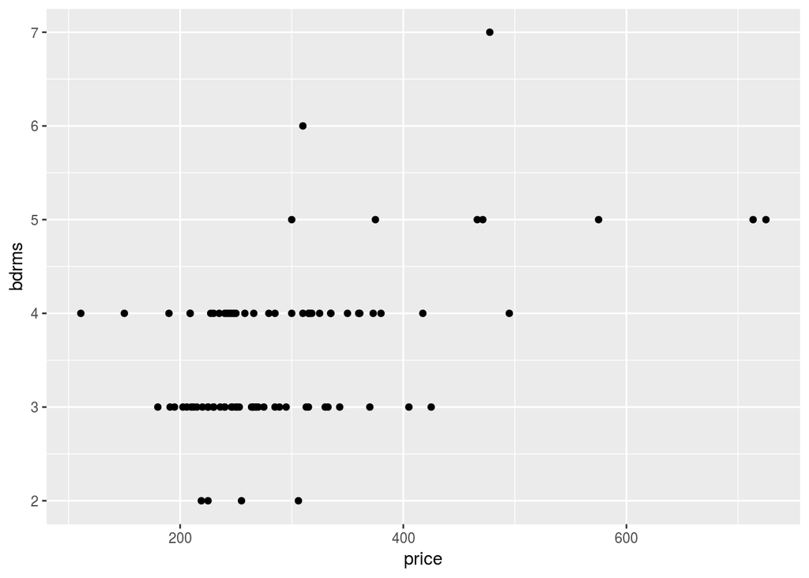

```r
hprice %>%
  ggplot(aes(price, bdrms))+
  geom_point(color="black")
```

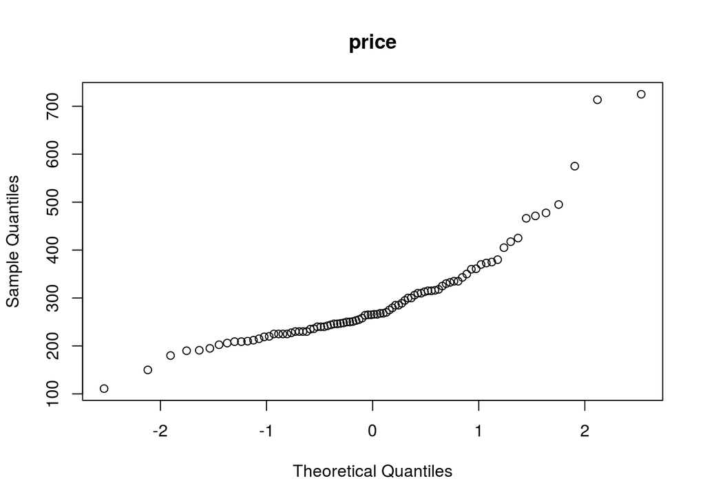

```r
qqnorm(hprice$price, main="price")
```

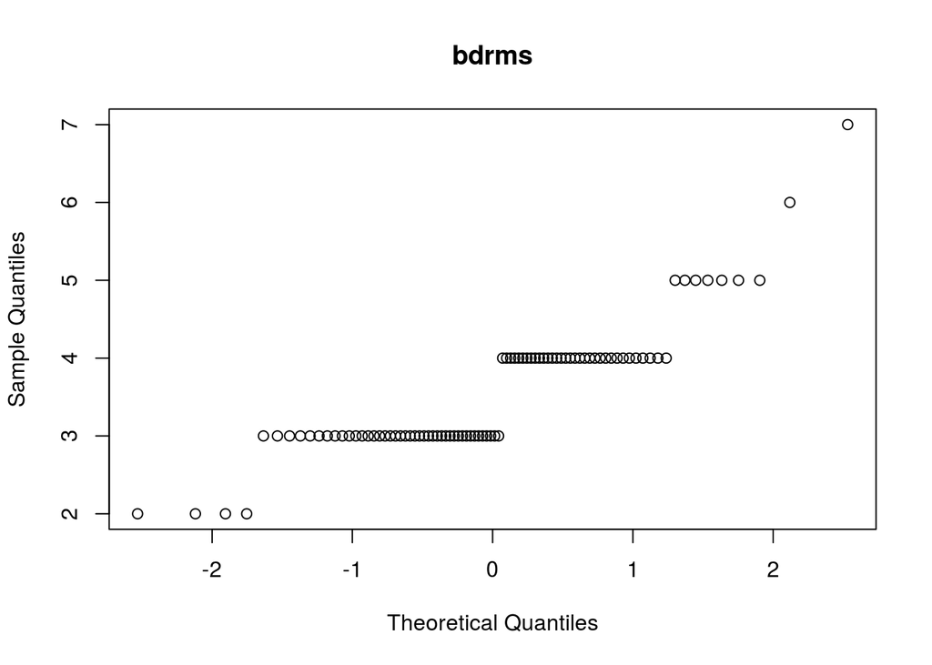

```r
qqnorm(hprice$bdrms, main="bdrms")
```

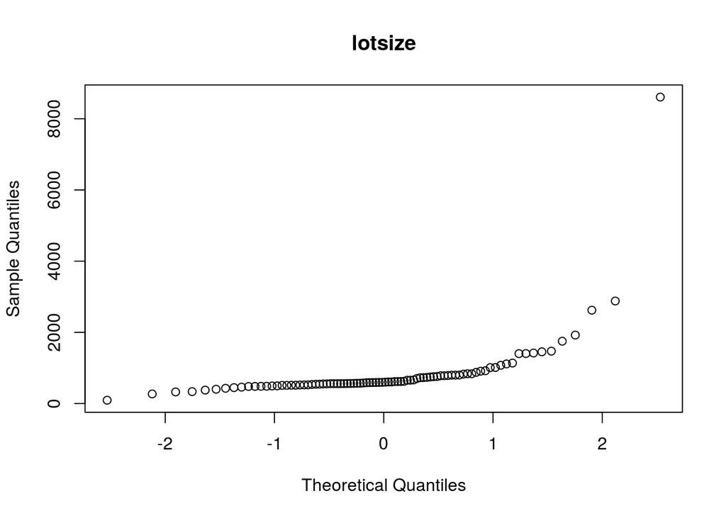

```r
qqnorm(hprice$lotsize, main="lotsize")
```

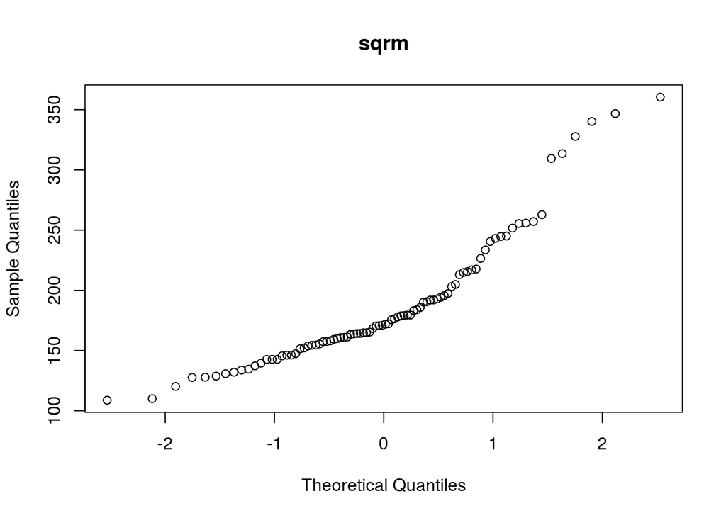

```r
qqnorm(hprice$sqrm, main="sqrm")
```

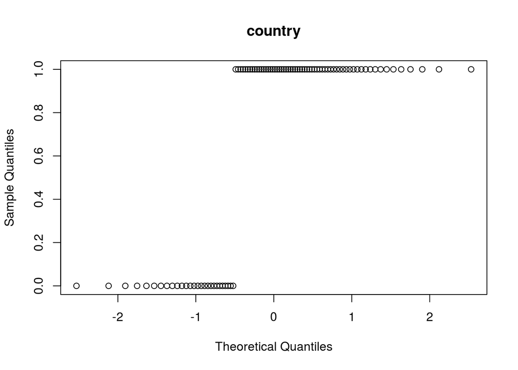

```r
qqnorm(hprice$country, main="country")
```

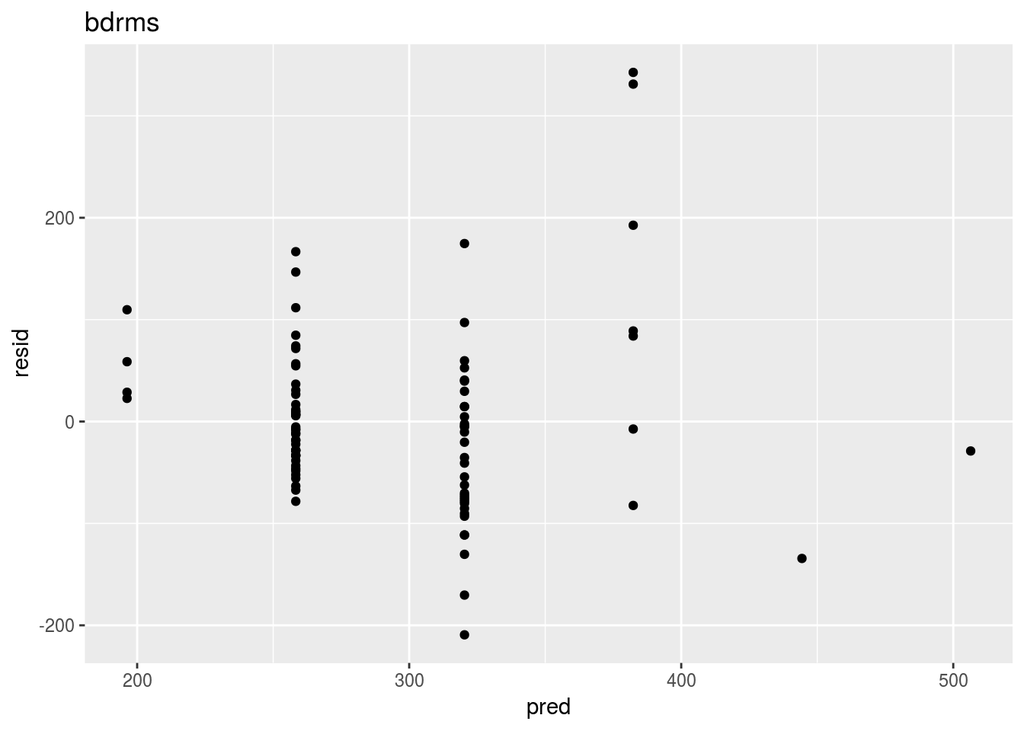

```r
hprice %>%
  add_predictions(fitb) %>%
  add_residuals(fitb) %>%
  ggplot(aes(pred, resid)) +
  geom_point() +
  ggtitle("bdrms")
```

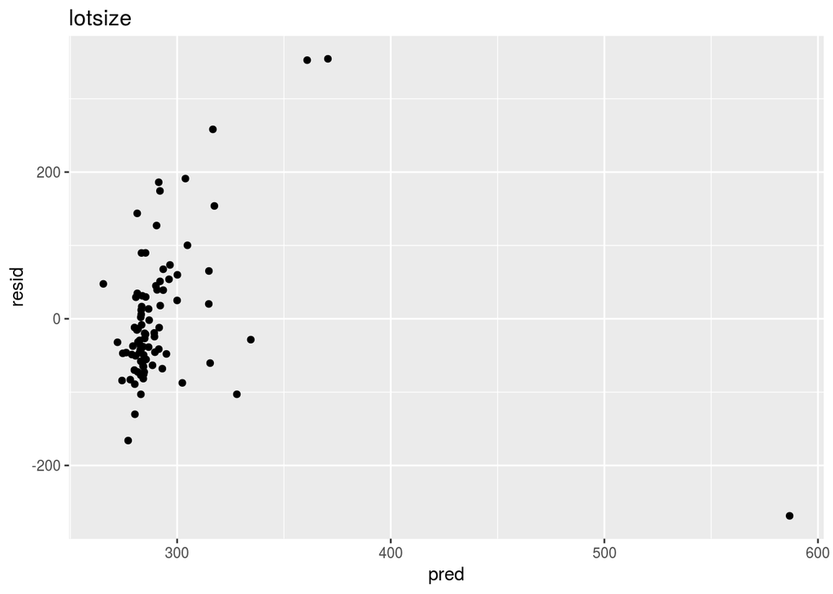

```r
hprice %>%
  add_predictions(fitl) %>%
  add_residuals(fitl) %>%
  ggplot(aes(pred, resid)) +
  geom_point() +
  ggtitle("lotsize")
```

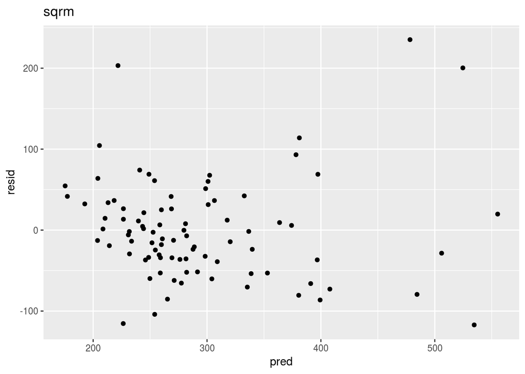

```r
hprice %>%
  add_predictions(fits) %>%
  add_residuals(fits) %>%
  ggplot(aes(pred, resid)) +
  geom_point()  +
  ggtitle("sqrm")
```

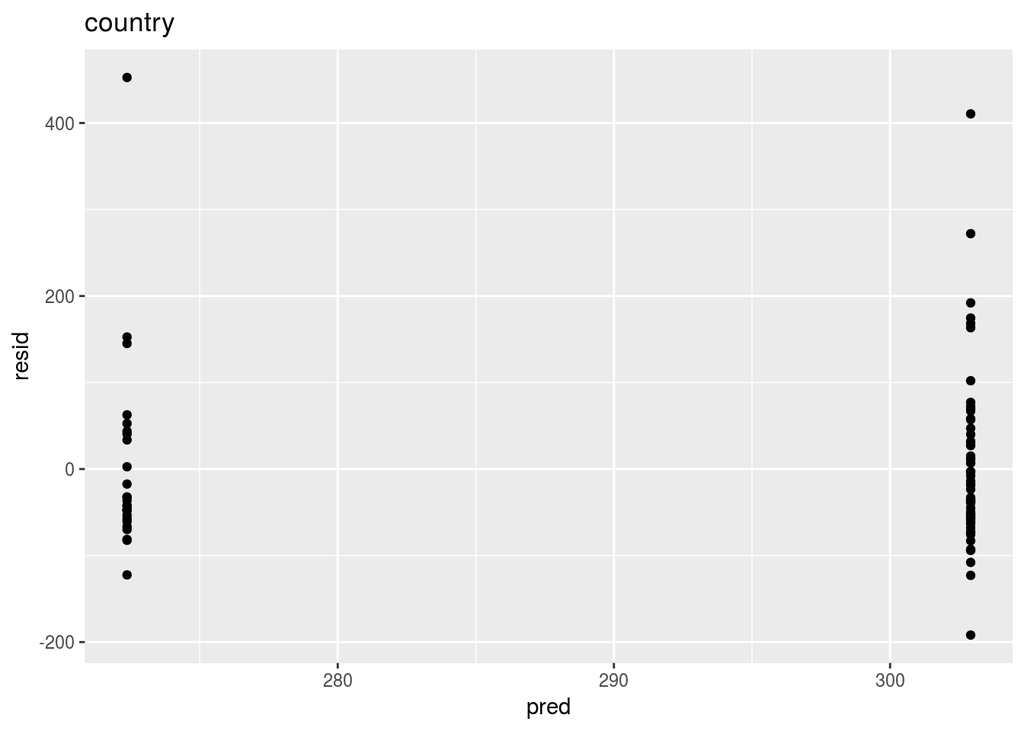

```r
hprice %>%
  add_predictions(fitc) %>%
  add_residuals(fitc) %>%
  ggplot(aes(pred, resid)) +
  geom_point()  +
  ggtitle("country")
```

2. Gegeben Sei das lineare Regressionsmodell aus Aufgabe 1.
   1. Erstellen Sie jeweils einen Scatterplot zur Darstellung des Zusammenhangs zwischen vorhergesagtem Wert für `price` und Residuengröße.

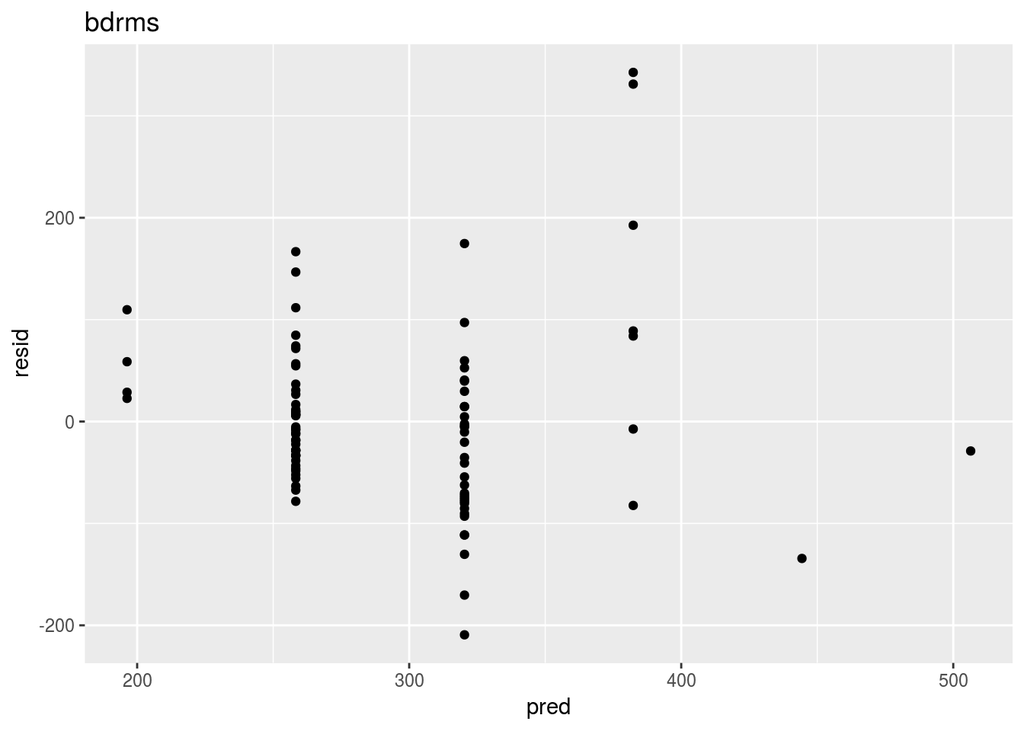

```r
hprice %>%
  add_predictions(fitb) %>%
  add_residuals(fitb) %>%
  ggplot(aes(pred, resid)) +
  geom_point() +
  ggtitle("bdrms")
```

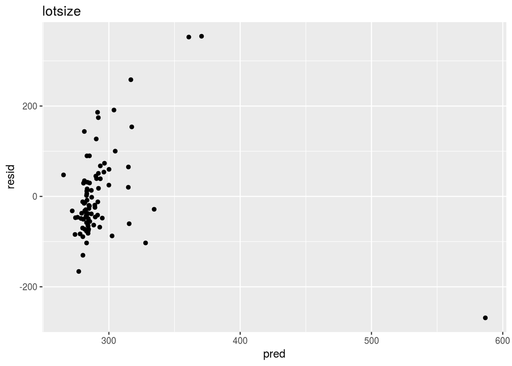

```r
hprice %>%
  add_predictions(fitl) %>%
  add_residuals(fitl) %>%
  ggplot(aes(pred, resid)) +
  geom_point() +
  ggtitle("lotsize")
```

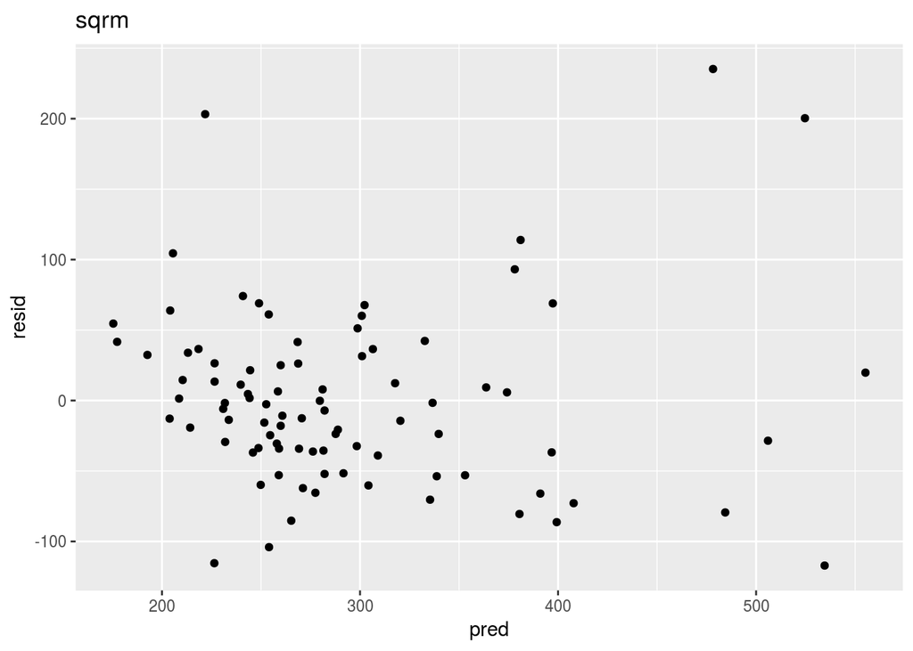

```r
hprice %>%
  add_predictions(fits) %>%
  add_residuals(fits) %>%
  ggplot(aes(pred, resid)) +
  geom_point()  +
  ggtitle("sqrm")
```

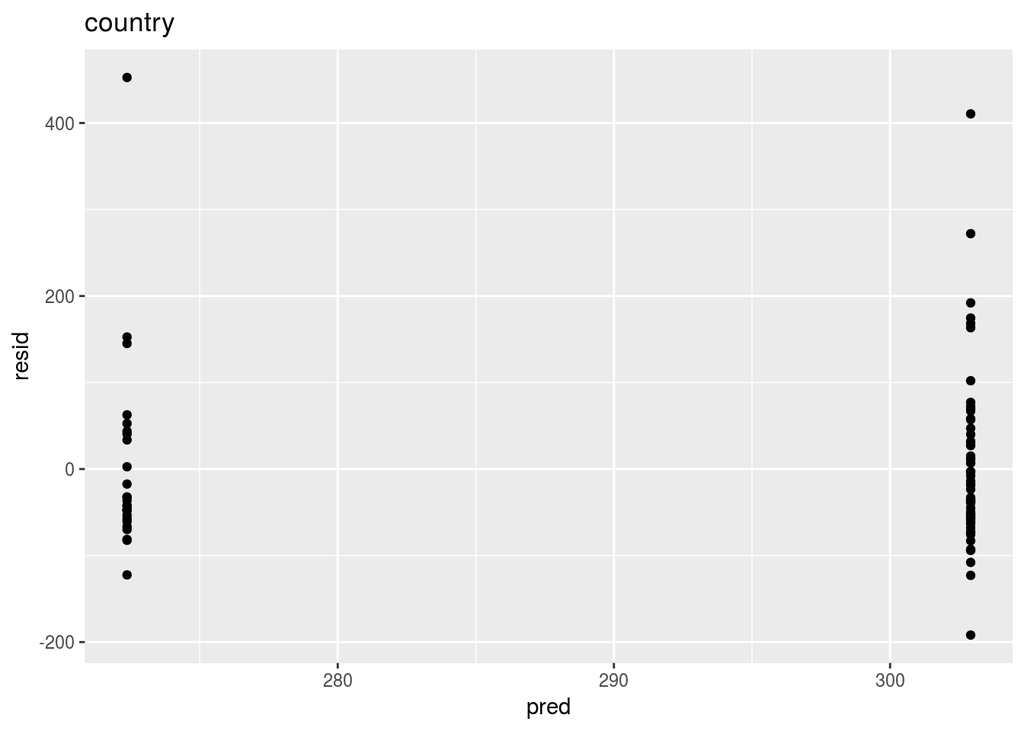

```r
hprice %>%
  add_predictions(fitc) %>%
  add_residuals(fitc) %>%
  ggplot(aes(pred, resid)) +
  geom_point()  +
  ggtitle("country")
```

b) Für einige Häuser liegt die Preisvorhersage des Makler-Modells um mehr als 100,000 EUR daneben. Heben Sie Häuser mit einer Residuengröße von mehr als 100 bzw. weniger als 100 hervor. Was könnten die Gründe für hohe Modellungenauigkeiten sein?

```r
for(i in (1:88)){
  if(fitb$residuals[i] > 100 | fitb$residuals < -100)
    print(paste0("b: ",i))
  if(fitl$residuals[i] > 100 | fitb$residuals < -100)
    print(paste0("l: ",i))
  if(fits$residuals[i] > 100 | fitb$residuals < -100)
    print(paste0("s: ",i))
  if(fitc$residuals[i] > 100 | fitb$residuals < -100)
    print(paste0("c: ",i))
}
```

```
## [1] "b: 2"
## [1] "l: 6"
## [1] "c: 6"
## [1] "b: 13"
## [1] "l: 13"
## [1] "c: 13"
## [1] "l: 29"
## [1] "c: 29"
## [1] "b: 38"
## [1] "l: 38"
## [1] "c: 38"
## [1] "b: 42"
## [1] "l: 42"
## [1] "s: 42"
## [1] "c: 42"
```

[output cut: 18 more lines]

```
c) Lässt sich der $R^2$-Wert erhöhen, indem eine Lineartransformation einer der unabhängigen Variablen verwendet wird?
```

3. Stellen Sie den Zusammenhang zwischen `bdrms` und `price` grafisch dar. Überprüfen Sie, ob sich dieser Zusammenhang auch im Regressionsmodell aus Aufgabe 1 widerspiegelt. Erstellen Sie ein Regressionsmodell mit `bdrms` als alleiniger unabhängigen Variable. Vergleichen Sie die Regressionskoeffizienten mit dem des Modells aus Aufgabe 1 und interpretieren Sie die Unterschiede.

[figure not shown]

```r
hprice %>%
  ggplot(aes(price, bdrms))
```

Datensatz:

- http://isgwww.cs.uni-magdeburg.de/cv/lehre/VisAnalytics/material/exercise/datasets/hprice.csv